# PCL 2022 Swings on Balls Analysis

Brandon Flores

9/25/2022

First we query our pitch by pitch database to retrieve each pitch that would be considered a ball by the automated balls/strikes system. For our analysis we decide whether a pitch is a ball by using the given data points for the bottom and top of the strikezone for each player as well as using -0.95 and 0.95 for our x-axis as homeplate measures 17” wide, and we also take into account about half the diameter of the baseball.

```r
balls_query <- "
SELECT *
FROM data.data
WHERE details_description = 'Swinging Strike'
OR details_description = 'Ball'
OR details_description = 'Foul'
OR details_description = 'In Play, no out'
OR details_description = 'In Play, out(s)'
OR details_description = 'In Play, run(s)'
;
"
balls <- dbGetQuery(con, balls_query) %>%
  group_by(game_date) %>%
  mutate(is_ball = case_when(pitch_data_coordinates_p_x - 0.95 > 0 |
                               -0.95 - pitch_data_coordinates_p_x > 0 |
                               pitch_data_coordinates_p_z - pitch_data_strike_zone_top > 0 |
                               pitch_data_strike_zone_bottom - pitch_data_coordinates_p_z > 0 ~ "ball",
                             TRUE ~ "strike")) %>%
  filter(is_ball == "ball") %>%
  tabyl(game_date, details_description) %>%
  clean_names()
```

```r
swing_percent <- balls %>%
  mutate(swing_rat = (swinging_strike + foul +
                        in_play_no_out + in_play_out_s +
                        in_play_run_s) / ball) %>%
  select(swing_rat)
```

We now filter data points outside of our mean +/- 2 standard deviations to control for potential outliers.

```r
avg <- mean(swing_percent$swing_rat)
sd <- sd(swing_percent$swing_rat)

swing_percent <- swing_percent %>% filter(swing_rat < avg + 2 * sd,
                                          swing_rat > avg - 2 * sd)
```

The automated balls and strikes system was implemented on May 16, 2022. This is the 37th game of the season, and so we split the dataframe accordingly.

```r
swing_percent <- rowid_to_column(swing_percent,"index")
sp1 <- swing_percent %>% filter(index < 37)
sp2 <- swing_percent %>% filter(index >= 37)
```

Finally we create scatter plots for both before and after the automated strikezone is implemented and affix a regression line for each graph.

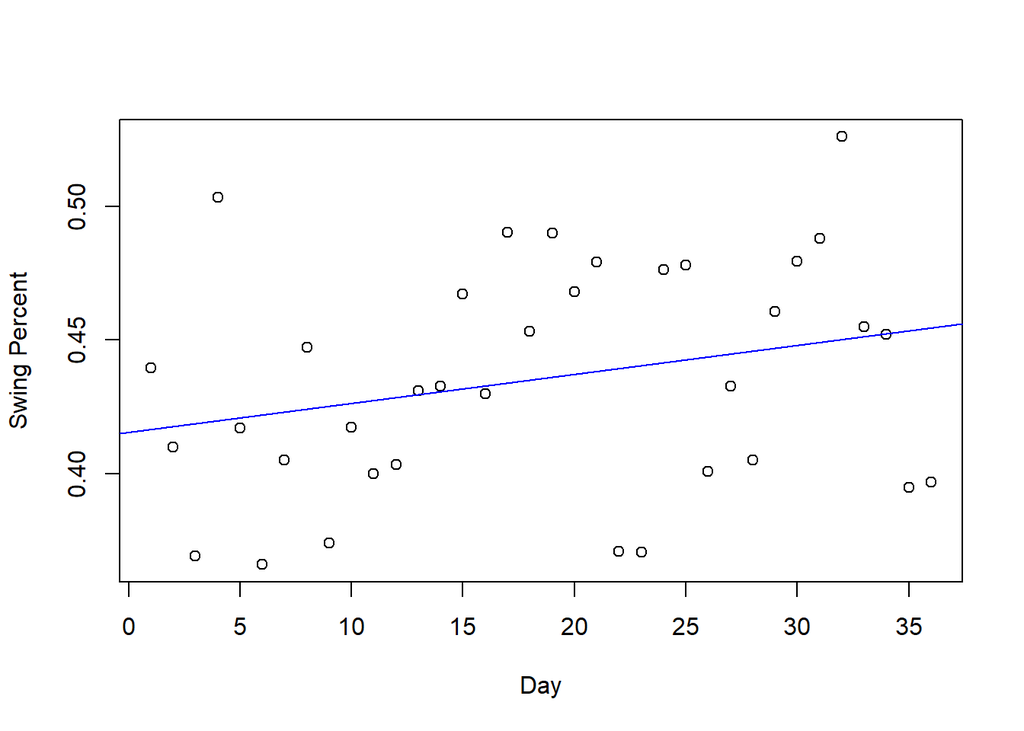

```r
plot(x = sp1$index, y = sp1$swing_rat,
     xlab = "Day", ylab = "Swing Percent")

abline(lm(swing_rat ~ index,data=sp1),col='blue')
```

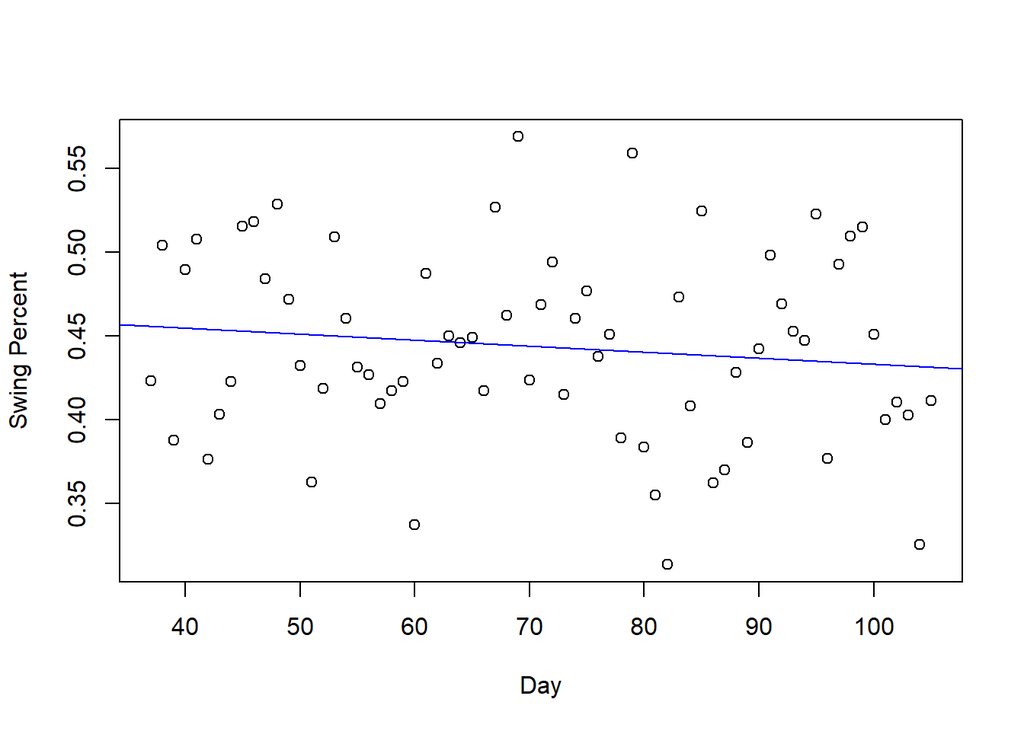

```r
plot(x = sp2$index, y = sp2$swing_rat,
     xlab = "Day", ylab = "Swing Percent")

abline(lm(swing_rat ~ index,data=sp2),col='blue')
```